# Homework 2: Using Spatial Lag, Spatial Error and Geographically Weighted Regression to Predict Median House Values in Philadelphia Block Groups

# Introduction

Median house values are an indicator of neighborhood economic health, and in Philadelphia they can be highly spatially variable. This report examines median house values at the Census block group level in Philadelphia. In our previous report, we used ordinary least squares (OLS) regression to examine the relationship between the natural log of median house value (LNMEDHVAL) and four neighborhood characteristics: the proportion of residents with at least a bachelor’s degree (PCTBACHMOR), the proportion of vacant housing units (PCTVACANT), the percentage of detached single-family homes (PCTSINGLES), and the natural log of the number of households living in poverty (LNNBELPOV). All four predictors were significant, and together they explained about 66% of the variation in LNMEDHVAL.

However, OLS is often inappropriate for datasets with a spatial component. Block groups that are close together tend to resemble one another, so their regression errors are likely to be correlated, which violates the OLS assumption that errors are independent. When this happens, standard errors and significance tests can be misleading. The purpose of this report is to use spatial lag, spatial error and geographically weighted regression (GWR) to account for this spatial dependence, and to determine whether these methods perform better than OLS in explaining median house values in Philadelphia.

# Methods

## A Description of the Concept of Spatial Autocorrelation

Spatial autocorrelation measures the degree to which values at nearby locations tend to be similar. It follows from Tobler’s First Law of Geography: everything is related to everything else, but near things are more related than distant things. If high values sit next to high values and low values sit next to low values, the variable has positive spatial autocorrelation. If neighbors tend to be different from each other, it has negative spatial autocorrelation. If values are arranged randomly, there is no spatial autocorrelation.

We measure global spatial autocorrelation with Moran’s I:

$$I = \frac{n}{\sum_{i}\sum_{j} w_{ij}}
\cdot \frac{\sum_{i}\sum_{j} w_{ij}\,(X_i - \bar{X})(X_j -
\bar{X})}{\sum_{i} (X_i - \bar{X})^2}$$

where $n$ is the number of block groups (1,720), $X_i$ is the value of the variable in block group $i$, $X_j$ is the value in block group $j$, $\bar{X}$ is the mean of the variable, and $w_{ij}$ is the spatial weight between block groups $i$ and $j$. The numerator is considered large and positive when a block group and its neighbors are both above the mean or both below it. The denominator is the total variance of the variable, which puts the statistic on a standard scale. Moran’s I usually ranges from -1 (perfect dispersion) to 1 (perfect clustering), and its expected value under no spatial autocorrelation is $-1/(n-1)$, which is close to 0.

In this report, we use a Queen contiguity weight matrix. Two block groups are neighbors if they share a border or a corner. In the matrix, $w_{ij} = 1$ if block groups $i$ and $j$ are neighbors and $w_{ij} = 0$ otherwise, and a block group is not its own neighbor ($w_{ii} = 0$). The matrix is row-standardized, meaning each weight is divided by the number of neighbors, so each row sums to 1. Every block group in our data has at least one neighbor, and the average block group has about 6.1 neighbors (range: 1 to 27). We will use this same weight matrix throughout the report.

At times, statisticians may run their analysis with more than one weight matrix, such as Rook contiguity, k-nearest neighbors, or a distance band since results can depend on how “neighbor” is defined. If the conclusions are similar across several weight matrices, the results are robust and are less likely to be an artifact of one particular choice.

To test whether Moran’s I is significant, we use a random permutation test. The null hypothesis is that there is no spatial autocorrelation ($H_0: I = 0$), and the alternative hypothesis is that there is spatial autocorrelation ($H_a: I \neq 0$). In each permutation, the observed values are randomly shuffled across the block groups while the weight matrix stays the same, and Moran’s I is recalculated. We do this 999 times to build a reference distribution of Moran’s I under spatial randomness. The pseudo p-value is the number of permuted Moran’s I values at least as extreme as the observed value, plus 1, divided by 1,000. If the pseudo p-value is less than 0.05, we reject the null hypothesis.

Global Moran’s I gives a single value for the entire city. Local Moran’s I, also called a Local Indicator of Spatial Association (LISA), calculates a separate value for each block group to show where clustering happens. Each block group is placed into one of four categories based on its own value and the average value of its neighbors, compared to the citywide mean. High-High and Low-Low block groups are clusters of similar values. High-Low and Low-High block groups are spatial outliers, where one block group is very different from its neighbors. To test significance, the value of block group $i$ is held fixed while the values of the other block groups are randomly shuffled among its neighbors 999 times. This gives a pseudo p-value for each block group. The significance map shows these p-values, and the cluster map shows the four categories for block groups that are significant at p ≤ 0.05.

## A Review of OLS Regression and Assumptions

The spatial autocorrelation tests described above can also be applied to regression residuals, which is how we check one of the key assumptions of OLS regression. In our HW 1 report, we used OLS regression to model the relationship between median house values and four neighborhood characteristics:

$$LNMEDHVAL_i = \beta_0 + \beta_1
PCTVACANT_i + \beta_2 PCTSINGLES_i + \beta_3 PCTBACHMOR_i + \beta_4
LNNBELPOV_i + \varepsilon_i$$

where $LNMEDHVAL_i$ is the natural log of median house value in block group $i$, $\beta_0$ is the intercept, $\beta_1$ through $\beta_4$ are the coefficients of the four predictors, and $\varepsilon_i$ is the residual (error) for block group $i$. OLS chooses the coefficients that minimize the sum of squared residuals, $\sum_i (y_i - \hat{y}_i)^2$, where $y_i$ is the observed value of LNMEDHVAL and $\hat{y}_i$ is the value predicted by the model.

OLS regression rests on five main assumptions. The first is linearity: the relationship between the dependent variable and each predictor should be a straight line, so a one-unit increase in a predictor is associated with the same change in the dependent variable no matter where on the scale it occurs. The second is independence of observations, meaning the residual for one block group should tell us nothing about the residual for any other. This is the assumption most likely to fail with spatial data.

The third assumption is homoscedasticity where the residuals should have roughly the same variance at every predicted value. When the spread of the residuals changes across predicted values (heteroscedasticity), the standard errors are no longer accurate, and neither are the p-values based on them. The fourth is that residuals should follow a normal distribution centered on zero. This matters most for the validity of the t-tests and the F-test.

The last assumption is that there is no severe multicollinearity, meaning the predictors should not be too strongly correlated with one another. When two predictors move closely together, the model has trouble separating their individual effects, which leads to inflated standard errors and unstable coefficient estimates. Multicollinearity concerns only the relationships among predictors. A strong correlation between the dependent variable and a predictor is a good thing, since it means that predictor helps explain the outcome.

OLS also requires a continuous dependent variable and enough observations, usually at least 10 per predictor. When data have a spatial component, the assumption that residuals are independent often does not hold. Block groups that are close together tend to have similar residuals. We can test this by calculating Moran’s I of the OLS residuals, using the same Queen weight matrix and 999 permutations.

Another way to test for spatial autocorrelation in the residuals is to regress the OLS residuals on the residuals of neighboring block groups. First, we calculate the weighted residual for each block group:

$$WT\_RESIDU_i = \sum_{j} w_{ij}\,
\varepsilon_j$$

where $\varepsilon_j$ is the OLS residual of block group $j$ and $w_{ij}$ is the row-standardized Queen weight. Since each row of weights sums to 1, $WT\_RESIDU_i$ is simply the average residual of block group $i$’s neighbors. Then we run a simple regression:

$$OLS\_RESIDU_i = a + b \cdot WT\_RESIDU_i
+ e_i$$

The slope $b$, shown as *Slope b* below the scatterplot of OLS_RESIDU and WT_RESIDU, tells us how strongly a block group’s residual is related to its neighbors’ residuals. We test $H_0: b = 0$ against $H_a: b \neq 0$. If $b$ is positive and significant, the residuals are spatially autocorrelated.

R can also test the other OLS assumptions. The first is homoscedasticity, which means the residuals have constant variance. This assumption is related to independence of errors. We test for heteroscedasticity using the Breusch-Pagan test, the Koenker-Bassett test (a version of Breusch-Pagan that does not require normally distributed residuals), and the White test (which also includes squared terms and interactions of the predictors). For all three tests, the null hypothesis is homoscedasticity, and the alternative hypothesis is heteroscedasticity.

The second is normality of residuals, which we test using the Jarque-Bera test. This test checks whether the skewness and kurtosis of the residuals match those of a normal distribution. The null hypothesis is that the residuals are normally distributed, and the alternative hypothesis is that they are not.

## Spatial Lag and Spatial Error Regression

We ran the spatial lag and spatial error regressions in R, using the spdep and spatialreg packages. Both models use the row-standardized Queen contiguity weight matrix described in the previous subsection and are estimated by maximum likelihood. The dependent variable and the predictors are the same as in the OLS model.

The spatial lag model is appropriate when the value of the dependent variable in one location depends directly on the values in neighboring locations. Here, the median house value in a block group is partly shaped by the median house values of the block groups that touch it. The model adds a spatially lagged dependent variable (the weighted average of neighboring values) as an additional predictor:

$$LNMEDHVAL_i = \rho \sum_{j} w_{ij}\,
LNMEDHVAL_j + \beta_0 + \beta_1 PCTVACANT_i + \beta_2 PCTSINGLES_i +
\beta_3 PCTBACHMOR_i + \beta_4 LNNBELPOV_i + \varepsilon_i$$
Here $LNMEDHVAL_i$ is the dependent variable for block group $i$. The term $w_{ij}$ is the row-standardized weight between block groups $i$ and $j$ (nonzero only if they are Queen neighbors), so $\sum_j w_{ij} LNMEDHVAL_j$ is the average value among the neighbors of block group $i$. The coefficient $\rho$ is the spatial lag parameter, which measures the strength of the dependence on neighboring values. The term $\beta_0$ is the intercept, $\beta_1$ through $\beta_4$ are the coefficients of the four predictors, and $\varepsilon_i$ is the random error, assumed to be independent with constant variance.

The spatial error model is appropriate when the spatial dependence operates through the errors rather than through the dependent variable itself. This can happen when important variables that are themselves spatially patterned are omitted from the model, or when the scale of the data does not match the scale of the underlying process. The model is:

$$LNMEDHVAL_i = \beta_0 + \beta_1
PCTVACANT_i + \beta_2 PCTSINGLES_i + \beta_3 PCTBACHMOR_i + \beta_4
LNNBELPOV_i + u_i$$
$$u_i = \lambda
\sum_{j} w_{ij}\, u_j + \varepsilon_i$$

Here $u_i$ is the spatially correlated error for block group $i$, equal to $\lambda$ times the weighted average of the errors of its neighbors plus a random component. The coefficient $\lambda$ is the spatial error parameter, which measures the strength of the spatial dependence in the errors. The term $\varepsilon_i$ is the independent random error, and $\beta_0$ through $\beta_4$ and $w_{ij}$ are defined as above.

The other assumptions of OLS (linearity, normality of errors, homoscedasticity, and no severe multicollinearity) are still required for both models. Only the assumption of independence of observations is relaxed. The goal of both methods is to account for the spatial dependence in the data so that the regression residuals no longer exhibit spatial autocorrelation. We compare the spatial lag model with OLS, and the spatial error model with OLS, using several criteria, and decide whether the spatial models perform better.

The log likelihood measures how well a model fits the data and is the quantity maximized in maximum likelihood estimation. A higher (less negative) log likelihood indicates a better fit.

Akaike Information Criterion (AIC) and Schwarz Criterion (SC). These are defined as $AIC = 2k - 2\ln(\hat{L})$ and $SC = k\ln(n) - 2\ln(\hat{L})$, where $k$ is the number of estimated parameters, $n$ is the number of observations and $\hat{L}$ is the maximized likelihood. Both reward fit while penalizing the number of parameters, and SC penalizes more heavily. The model with the lower AIC and SC is preferred. Unlike the likelihood ratio test, these criteria can also be used to compare non-nested models, such as the spatial lag and spatial error models.

Likelihood ratio test. OLS is a special case of both spatial models (when $\rho = 0$ or $\lambda = 0$), so it is nested within each, and the likelihood ratio test applies. The test statistic is $LR = 2(\ln L_{spatial} - \ln L_{OLS})$, which follows a chi-squared distribution with one degree of freedom. The null hypothesis is that the OLS model fits as well as the spatial model (the spatial parameter equals zero), and the alternative is that the spatial model fits significantly better. A p-value below 0.05 leads us to reject the null in favor of the spatial model. The test cannot be used to compare the spatial lag model with the spatial error model, because neither is nested within the other.

Breusch-Pagan test. For each spatial model we also test the residuals for heteroscedasticity. The null hypothesis is that the errors have constant variance, and the alternative is that the variance changes with the predictors. A p-value below 0.05 indicates that heteroscedasticity remains.

A further way to compare OLS with the spatial models is to examine the Moran’s I of the regression residuals, using 999 random permutations to assess significance, as described earlier. If a spatial model has accounted for the spatial dependence, the Moran’s I of its residuals should be close to zero and lower in magnitude than the Moran’s I of the OLS residuals. The model with the smaller residual Moran’s I (closer to zero) is considered to do a better job of removing spatial autocorrelation.

## Geographically Weighted Regression

Lastly, in our analysis, we will run a geographically weighted regression (GWR) in R. The GWR equation is as follows:
$$y_i = \beta_0(u_i, v_i) + \sum_{k=1}^{p}
\beta_k(u_i, v_i) x_{ik} + \varepsilon_i$$
By running a GWR, we can better understand the effect of the variable from place to place. In statistics, we may observe that a trend in subgroups reverses or disappears once the groups are combined (Simpson’s paradox.) A local regression can fit a separate regression to the data to a specific neighborhood or localized prediction point. Nearby locations are weighted more heavily witha. kernel. We can do this for a GWR by altering the bandwidth. We have two options for bandwidth; fixed and adaptive. In our analysis, we will be using an adaptive bandwidth. A fixed bandwidth has a constant physical distance as the spatial kernel whereas an adaptive bandwidth bases the size of the spatial kernel on a constant number of nearest neighbors. In our case, the adaptive bandwidth is the most appropriate since the number of households and block groups vary by size. Adaptive bandwidth is best for data with heterogeneous data distributions, in this case, houses per census block is varied and not uniform.

OLS assumptions still hold in GWR. The variables must be linear in terms of coefficients and error. The error has a mean population of zero. The independent variables and their observations are not correlated with the error. The error term has constant variance and is normally distributed. None of the independent variables have a perfect linear relationship with each other. We try to avoid multicollinearity, when the independent variables are highly correlated with one another. One way to determine the strength of multicollinearity is through a condition number, the ratio of the largest and smallest singular values in a correlation matrix. We mention this because multicollinearity tends to occur in GWR because the sample size gets smaller when we cluster groups for a weighted regression. In that, there’s less spatial variance which may lead to multicollinearity since these clusters only have each other to compare to for a relationship, making the data more sensitive to change. We may diagnose multicollinearity in our model with a condition number that is output from our GWR. If that number is greater than 30, or null, we may assume that local multicollinearity is occurring, making this estimate unstable.

# Results

## Spatial Autocorrelation

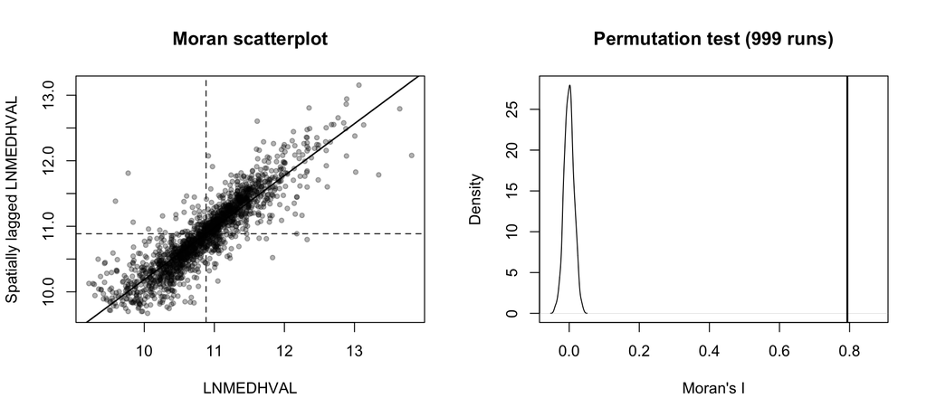

Figure 1. Global Moran’s I of LNMEDHVAL: Moran scatterplot (left) and 999-permutation distribution (right).

The global Moran’s I of LNMEDHVAL is 0.794. In the Moran scatterplot (Figure 1, left), most block groups fall in the High-High (upper right) and Low-Low (lower left) quadrants, and the fitted line, whose slope equals Moran’s I, rises steeply. In the permutation test (Figure 1, right), the 999 permuted values are centered around 0 and none comes close to the observed value, giving a pseudo p-value of < 0.001. We reject the null hypothesis of no spatial autocorrelation and conclude that LNMEDHVAL is significantly and positively spatially autocorrelated. Block groups with high house values tend to be near other high-value block groups, and block groups with low values tend to be near other low-value block groups.

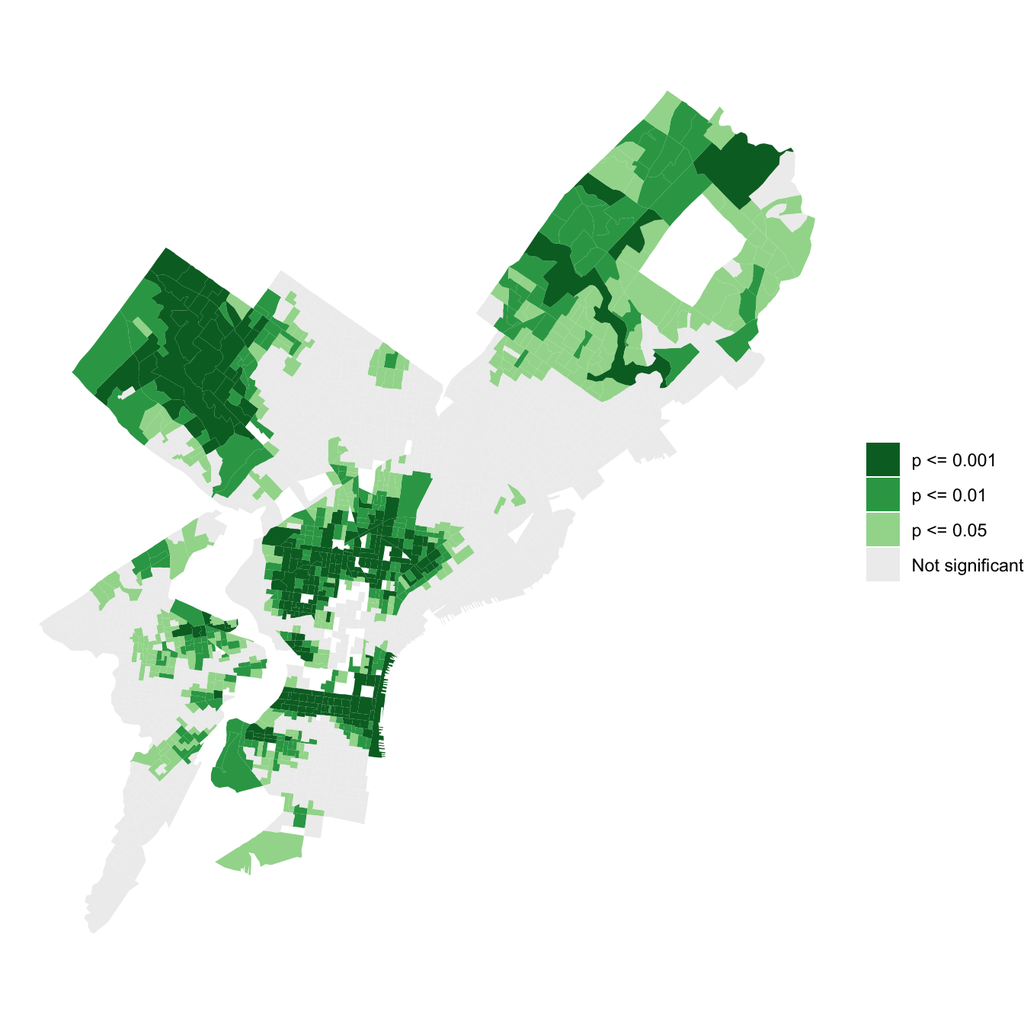

Figure 2. LISA significance map of LNMEDHVAL (999 permutations).

The significance map (Figure 2) shows that local spatial autocorrelation is concentrated in a few parts of the city. The strongest results (p ≤ 0.001) appear in the Northwest, in North Philadelphia, in Center City, and in parts of the Northeast. West and Southwest Philadelphia have scattered block groups that are significant at the 0.01 or 0.05 level. A large area running through the lower Northeast, along with most of South Philadelphia, is not significant, meaning house values there are not more similar to their neighbors’ than we would expect by chance.

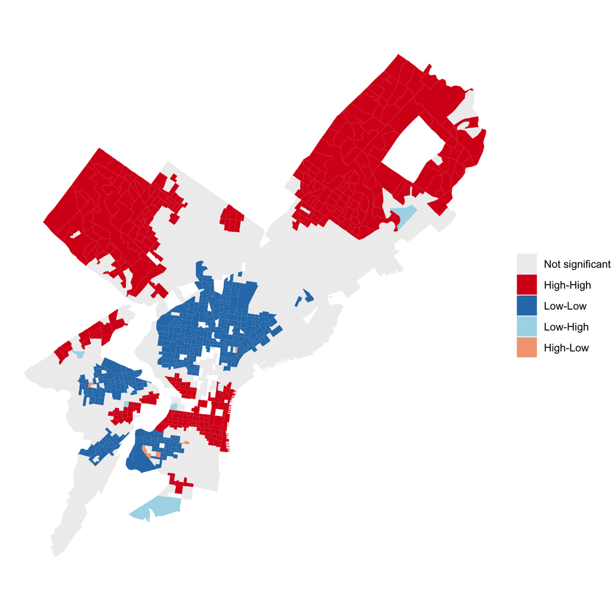

Figure 3. LISA cluster map of LNMEDHVAL (p ≤ 0.05).

Figures 2 and 3 show the local Moran’s I results. Of the 1,720 block groups, 349 are High-High, 406 are Low-Low, 5 are High-Low, 5 are Low-High, and 955 are not significant.

The cluster map (Figure 3) shows two very different parts of the city. The largest High-High clusters, where high-value block groups are surrounded by other high-value block groups, cover the Northwest and most of the Northeast. A second High-High area runs through Center City and along the Delaware river. Smaller High-High clusters appear in University City. The main Low-Low cluster covers a large, continuous area of North Philadelphia. Smaller Low-Low clusters appear in West & Southwest Philadelphia, and the area just southwest of Center City. High-Low and Low-High block groups are spatial outliers. Most sit at the edges of larger clusters, such as the Low-High block group next to the Northeast High-High cluster and the High-Low block groups inside the Low-Low area south of Center City.

## A Review of OLS Regression and Assumptions: Results

Table 1. OLS regression results (dependent variable: LNMEDHVAL)

|  | Estimate | Std. Error | t value | Pr(>\|t\|) |
| --- | --- | --- | --- | --- |
| (Intercept) | 11.1138 | 0.0465 | 238.8428 | < 0.001 |
| PCTVACANT | -0.0192 | 0.0010 | -19.5902 | < 0.001 |
| PCTSINGLES | 0.0030 | 0.0007 | 4.2337 | < 0.001 |
| PCTBACHMOR | 0.0209 | 0.0005 | 38.4944 | < 0.001 |
| LNNBELPOV | -0.0789 | 0.0085 | -9.3303 | < 0.001 |

Table 1 shows the OLS results. All four predictors are significant at p < 0.001. PCTBACHMOR and PCTSINGLES are positively associated with LNMEDHVAL, and PCTVACANT and LNNBELPOV are negatively associated with it. The model explains about 66% of the variance in LNMEDHVAL (R² = 0.662, adjusted R² = 0.662).

Table 1b. OLS residual diagnostics: heteroscedasticity and normality tests

| Test | Statistic | df | p-value |
| --- | --- | --- | --- |
| Breusch-Pagan | 113.19 | 4 | < 0.001 |
| Koenker-Bassett | 42.87 | 4 | < 0.001 |
| White | 111.32 | 14 | < 0.001 |
| Jarque-Bera | 778.96 | 2 | < 0.001 |

All three heteroscedasticity tests lead to the same conclusion (Table 1b). The Breusch-Pagan test (χ² = 113.19, p < 0.001), the Koenker-Bassett test (χ² = 42.87, p < 0.001), and the White test (χ² = 111.32, p < 0.001) are all significant, so we reject the null hypothesis of homoscedasticity. The variance of the OLS residuals is not constant, which violates the homoscedasticity assumption.

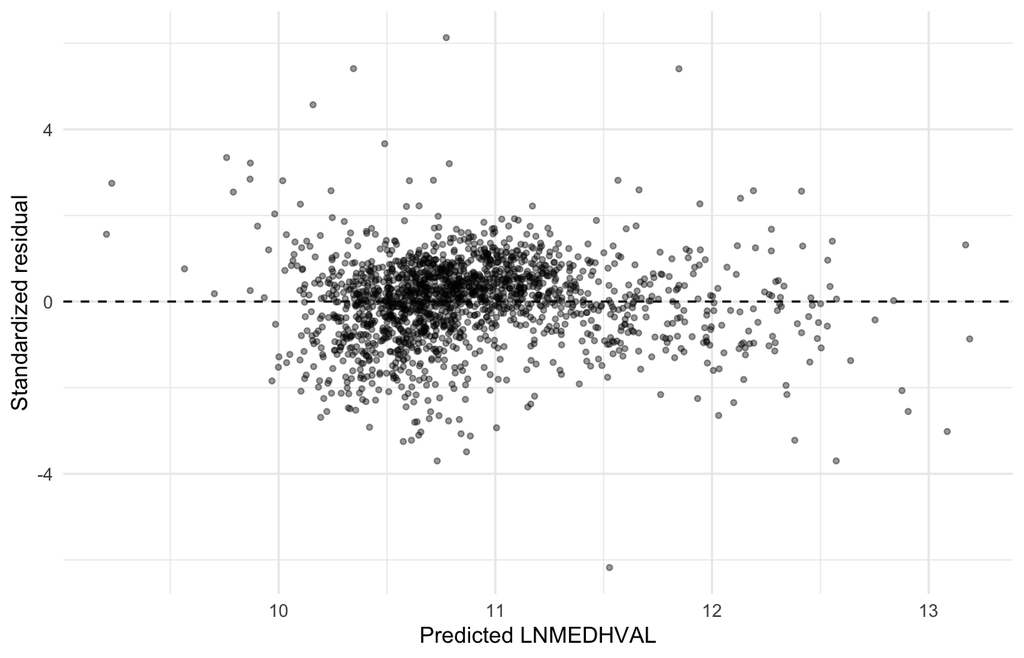

Figure 4. Standardized residuals by predicted values, OLS (from HW 1).

This is consistent with the plot of standardized residuals against predicted values from HW 1 (Figure 4). In HW 1, we noted that the spread of the residuals was mostly even but somewhat wider at the lowest and highest predicted values, which suggested mild heteroscedasticity. The formal tests confirm that this pattern is statistically significant.

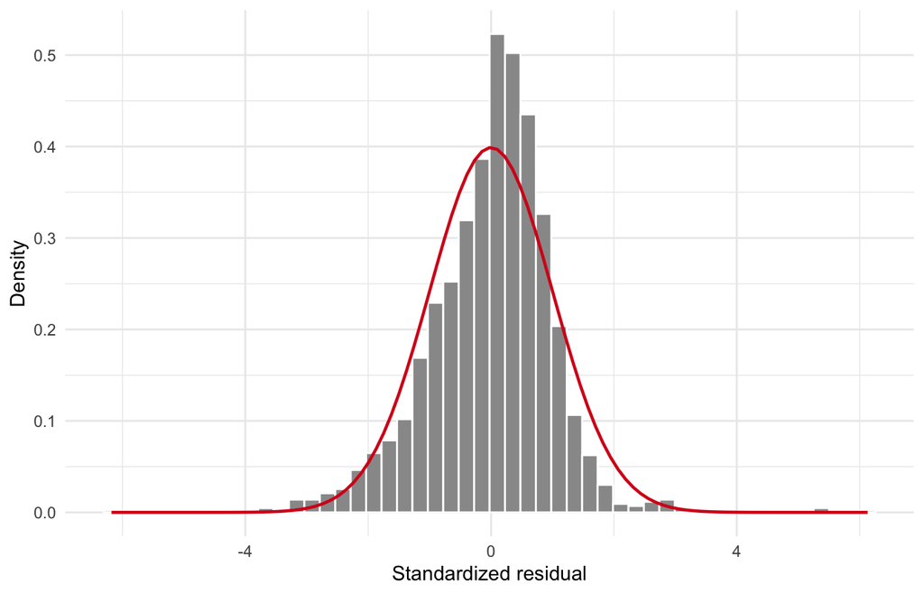

Figure 5. Histogram of standardized OLS residuals (from HW 1).

The Jarque-Bera test is significant (JB = 779, p < 0.001), so we reject the null hypothesis that the residuals are normally distributed. This is consistent with the histogram of standardized residuals from HW 1 (Figure 5). The histogram is centered at zero, but it has a taller, narrower peak than a normal curve, a slightly longer left tail, and a few extreme values near ±6 (kurtosis = 6.28, skewness = -0.16). With 1,720 observations, the Jarque-Bera test is sensitive enough to detect these heavy tails even though most residuals look close to normal.

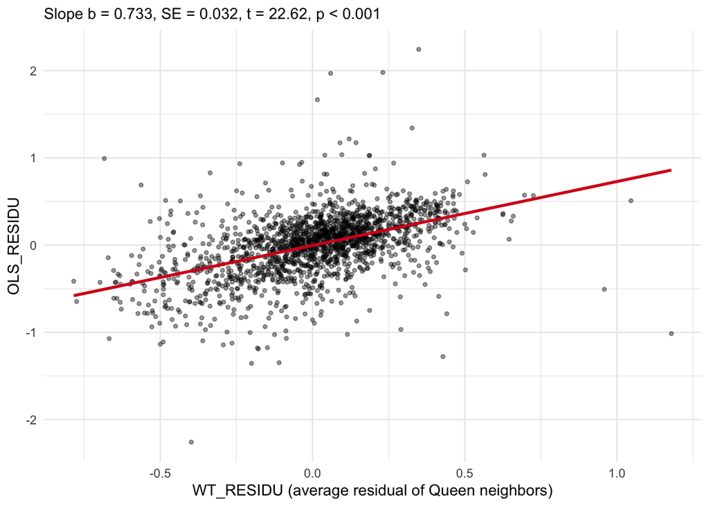

Figure 6. OLS residuals (OLS_RESIDU) plotted against weighted residuals of Queen neighbors (WT_RESIDU).

Figure 6 shows the OLS residuals plotted against the weighted residuals of their Queen neighbors. The points slope clearly upward, and Slope b is 0.733 (SE = 0.032, t = 22.62, p < 0.001). So, when the average residual of a block group’s neighbors increases by 1, the block group’s own residual increases by about 0.73 on average. Because Slope b is positive and significant, block groups tend to have residuals similar to their neighbors. Where the model underpredicts house values, it tends to underpredict them in neighboring block groups as well and significant spatial autocorrelation in the OLS residuals.

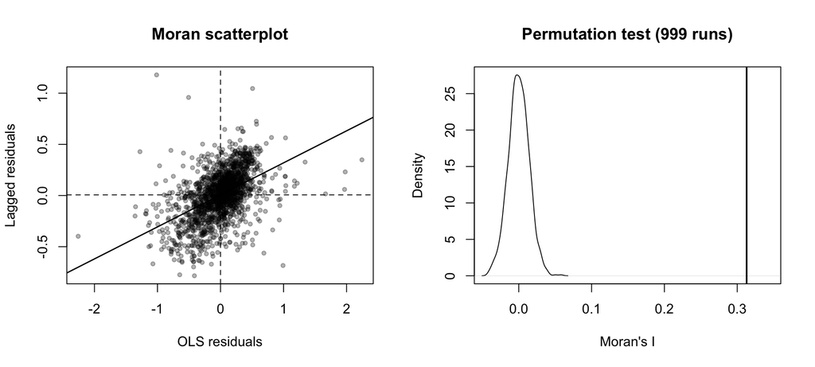

Figure 7. Moran’s I of OLS residuals: scatterplot (left) and 999-permutation distribution (right).

The Moran’s I of the OLS residuals is 0.313, with a pseudo p-value of < 0.001 from 999 permutations (Figure 7). In the Moran scatterplot, most block groups fall in the upper right and lower left quadrants, meaning that block groups with positive residuals tend to have neighbors with positive residuals, and the same is true for negative residuals. In the permutation test, the observed value lies far to the right of all 999 permuted values, which are centered around 0. We reject the null hypothesis and conclude that the OLS residuals are significantly and positively spatially autocorrelated.

This spatial autocorrelation is a problem because it violates the OLS assumption of independent observations. When residuals are spatially autocorrelated, OLS underestimates the standard errors, so the p-values are too small and the predictors may appear more significant than they really are. It also suggests that the model is missing variables that are themselves spatially patterned.

Moran’s I and Slope b are both positive and significant, indicating that the OLS residuals are spatially autocorrelated. We suggest a spatial regression model for this data. Slope b (0.733) is larger than Moran’s I (0.313) because the two statistics put the variables on opposite axes. Moran’s I is the slope of the neighbors’ average residual on a block group’s own residual, while Slope b is the slope of a block group’s own residual on its neighbors’ average. Averaging over several neighbors smooths out the residuals, so WT_RESIDU varies less than OLS_RESIDU, which makes Slope b larger.

## Spatial Lag and Spatial Error Regression Results

The Queen weight matrix links all 1,720 block groups, with an average of about six neighbors each, and no block group is without a neighbor. The OLS residuals are strongly spatially autocorrelated (Moran’s I = 0.313, p = 0.001 from 999 permutations), which motivates the spatial models below.

Table 2. Spatial lag regression results

|  | Estimate | Std. Error | z value | Pr(>\|z\|) |
| --- | --- | --- | --- | --- |
| Rho (W_LNMEDHVAL) | 0.6511 | 0.0181 | 36.0716 | 0e+00 |
| (Intercept) | 3.8985 | 0.2011 | 19.3843 | 0e+00 |
| PCTVACANT | -0.0085 | 0.0007 | -11.4694 | 0e+00 |
| PCTSINGLES | 0.0020 | 0.0005 | 3.9425 | 1e-04 |
| PCTBACHMOR | 0.0085 | 0.0005 | 16.3120 | 0e+00 |
| LNNBELPOV | -0.0341 | 0.0063 | -5.4116 | 0e+00 |

Table 2 presents the spatial lag regression results. The spatial lag term, W_LNMEDHVAL (Rho), is positive and highly significant (ρ = 0.651, z = 36.07, p < 0.0001). Holding the predictors constant, block groups tend to have higher median house values when their neighbors have higher values, so house values in Philadelphia are strongly spatially dependent. All four predictors remain significant at the 0.001 level, with the same signs as in OLS. PCTVACANT (-0.0085) and LNNBELPOV (-0.0341) are negatively associated with LNMEDHVAL, while PCTSINGLES (0.0020) and PCTBACHMOR (0.0085) are positively associated. However, the coefficients are noticeably smaller in magnitude than in OLS. For example, PCTBACHMOR falls from 0.0209 to 0.0085, PCTVACANT from -0.0192 to -0.0085, LNNBELPOV from -0.0789 to -0.0341, and PCTSINGLES from 0.0030 to 0.0020. This suggests that part of the apparent effect of the predictors in OLS was actually picking up the influence of neighboring values. Because of the lag term, these coefficients should not be read as the full effect of a predictor, since a change in one block group is also transmitted to its neighbors.

The Breusch-Pagan test on the spatial lag residuals is significant (BP = 51.41, df = 4, p < 0.0001), so we reject the null hypothesis of constant variance. The spatial lag residuals are still heteroscedastic.

Table 4. Comparison of OLS, spatial lag and spatial error models

| Model | LogLik | AIC | BIC |
| --- | --- | --- | --- |
| OLS | -711.49 | 1434.99 | 1467.69 |
| Spatial Lag | -255.74 | 525.48 | 563.63 |
| Spatial Error | -372.69 | 759.38 | 797.53 |

Table 4 compares the models. Relative to OLS, the spatial lag model has a much higher log likelihood (-255.74 vs. -711.49) and much lower AIC (525.48 vs. 1434.99) and SC (563.63 vs. 1467.69). The likelihood ratio test is also highly significant (LR = 911.51, df = 1, p < 0.0001), so we reject the null hypothesis that OLS fits as well as the spatial lag model. On every one of these criteria the spatial lag model is clearly better than OLS.

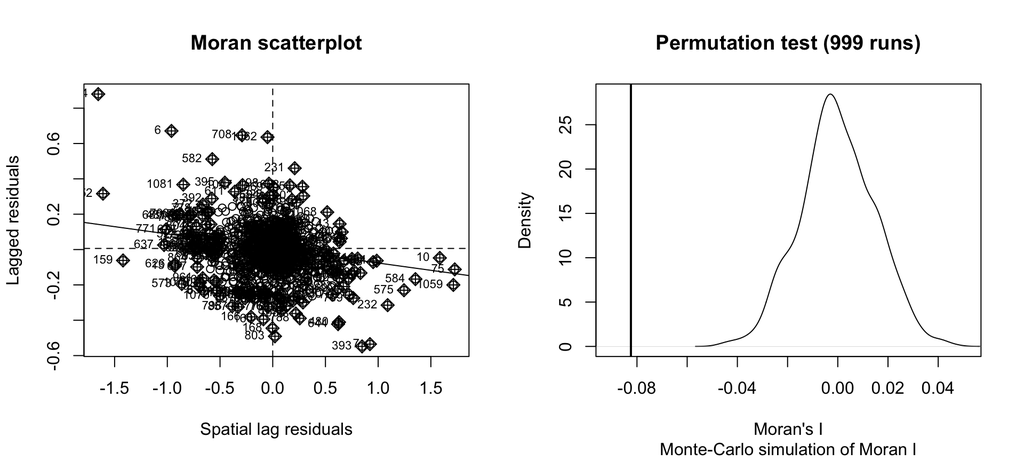

Figure 8. Moran’s I of spatial lag regression residuals: scatterplot (left) and 999-permutation distribution (right).

The Moran’s I of the spatial lag residuals is -0.082, compared with 0.313 for the OLS residuals, so the strong positive spatial autocorrelation present in OLS has been removed. The two-sided permutation test is significant (p = 0.002) only because the statistic falls slightly below the permuted values, indicating a small amount of negative autocorrelation, which is far weaker in magnitude than the original positive autocorrelation. Overall, the spatial lag model performs better than OLS on the log likelihood, AIC, SC, likelihood ratio test and residual spatial autocorrelation, although heteroscedasticity remains.

Table 3. Spatial error regression results (dependent variable: LNMEDHVAL)

|  | Estimate | Std. Error | z value | Pr(>\|z\|) |
| --- | --- | --- | --- | --- |
| Lambda | 0.8149 | 0.0164 | 49.7719 | 0 |
| (Intercept) | 10.9064 | 0.0535 | 203.9813 | 0 |
| PCTVACANT | -0.0058 | 0.0009 | -6.5220 | 0 |
| PCTSINGLES | 0.0027 | 0.0006 | 4.3134 | 0 |
| PCTBACHMOR | 0.0098 | 0.0007 | 13.4615 | 0 |
| LNNBELPOV | -0.0345 | 0.0071 | -4.8713 | 0 |

Table 3 presents the spatial error regression results. The spatial error term, Lambda, is positive and highly significant (λ = 0.815, z = 49.77, p < 0.0001). This indicates strong positive spatial dependence in the errors: the variation in house values not explained by the four predictors is similar among neighboring block groups, which is consistent with omitted variables that are themselves spatially patterned. All four predictors remain significant (p < 0.0001), with the same signs as in OLS: PCTVACANT (-0.0058), PCTSINGLES (0.0027), PCTBACHMOR (0.0098) and LNNBELPOV (-0.0345). As in the lag model, the coefficients for PCTVACANT, PCTBACHMOR and LNNBELPOV are smaller in magnitude than their OLS counterparts (-0.0192, 0.0209 and -0.0789), while PCTSINGLES (0.0027 vs. 0.0030) is nearly unchanged.

The Breusch-Pagan test on the spatial error residuals is not significant (BP = 5.16, df = 4, p = 0.271), so we fail to reject the null hypothesis of constant variance. Unlike the spatial lag model, there is no evidence of heteroscedasticity in the spatial error residuals.

Relative to OLS, the spatial error model has a higher log likelihood (-372.69 vs. -711.49) and lower AIC (759.38 vs. 1434.99) and SC (797.53 vs. 1467.69). The likelihood ratio test is highly significant (LR = 677.61, df = 1, p < 0.0001), so the spatial error model fits significantly better than OLS.

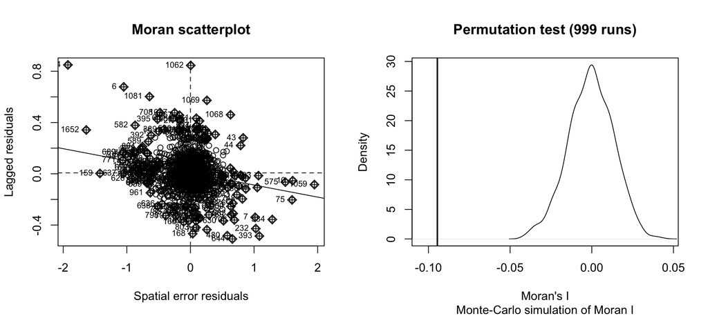

Figure 9. Moran’s I of spatial error regression residuals: scatterplot (left) and 999-permutation distribution (right).

The Moran’s I of the spatial error residuals is -0.095 (two-sided permutation p = 0.002), which is much closer to zero than the OLS value of 0.313, again leaving only a slight negative autocorrelation. Overall, the spatial error model performs better than OLS on every criterion, and it also resolves the heteroscedasticity problem.

Because neither model is nested within the other, we do not use the likelihood ratio test to compare them and rely instead on AIC and SC. The spatial lag model has the lower AIC (525.48 vs. 759.38) and the lower SC (563.63 vs. 797.53), as well as the higher log likelihood (-255.74 vs. -372.69), so it fits better than the spatial error model. Its residual Moran’s I (-0.082) is also slightly closer to zero than that of the spatial error model (-0.095). The one advantage of the spatial error model is that its residuals are not heteroscedastic, whereas the spatial lag residuals are. Overall, both spatial models improve substantially on OLS, and the spatial lag model is the better of the two on the fit criteria, though the remaining heteroscedasticity is a limitation that should be kept in mind.

## Geographically Weighted Regression Results

When comparing the AIC to the other models in our analysis, the Spatial Lag model outperforms all of the models with the lowest AIC of 525.5 in terms of fit. This is a large contrast from our first model, OLS, which had an AIC of 1435. The GWR model was second best at 660.7 and Spatial Error at third place 759.4.

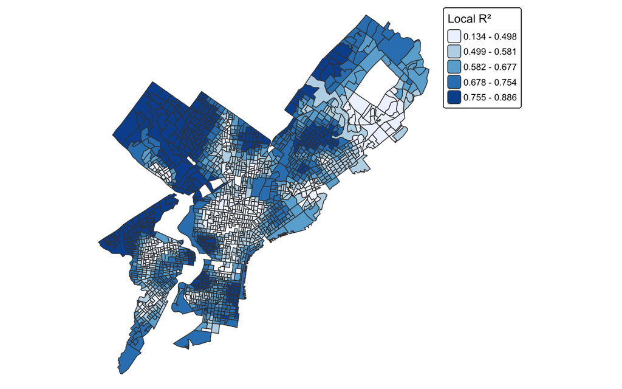

Figure 12. Local R-squared from the GWR.

Table 6. Share of block groups by coefficient / SE ratio

| Predictor | Ratio < -2 (%) | -2 to 2 (%) | Ratio > 2 (%) |
| --- | --- | --- | --- |
| PCTVACANT | 36.0 | 63.5 | 0.5 |
| PCTSINGLES | 13.9 | 69.7 | 16.4 |
| PCTBACHMOR | 0.0 | 31.3 | 68.7 |
| LNNBELPOV | 21.3 | 78.7 | 0.0 |

# Discussion

Our report examined the relationship between median house values and four neighborhood characteristics in Philadelphia using OLS, spatial lag, spatial error, and geographically weighted regression (GWR). The results show that median house values are positively spatially autocorrelated, and that the OLS residuals also exhibit significant positive spatial autocorrelation. Both spatial regression models improved on OLS, while the spatial lag model had the best overall fit based on log likelihood, AIC, and SC. GWR also improved model fit relative to OLS and revealed that the relationships between neighborhood characteristics and median house values vary across block groups. Among the GWR predictors, the percentage of residents with a bachelor’s degree or higher had the most consistent positive local association, while the other predictors showed more localized or spatially variable relationships.

There were several limitations to these models. The OLS residuals violated the assumptions of independent errors, constant variance, and normality: Moran’s I indicated significant spatial autocorrelation, the Breusch-Pagan, Koenker-Bassett, and White tests indicated heteroscedasticity, and the Jarque-Bera test indicated non-normal residuals. The spatial lag model reduced residual spatial autocorrelation but still exhibited heteroscedasticity. The spatial error model did not show significant residual heteroscedasticity and reduced spatial autocorrelation, although its residual Moran’s I remained significantly negative. GWR captured local variation, but local estimates may be unstable where multicollinearity is high, and local coefficient significance should be interpreted cautiously because many locations are tested. The models also include only four neighborhood predictors, so omitted factors may explain additional variation in house values. Based on the reported fit statistics, the spatial lag model performed best overall, although its remaining heteroscedasticity is an important limitation.

Weighted (spatially lagged) residuals are different from spatial lag model residuals. The weighted residual used in the OLS diagnostic is the average of neighboring block groups’ OLS residuals, calculated using the Queen contiguity weights. Regressing the OLS residuals on this weighted residual helps test whether a block group’s unexplained error is related to the errors of its neighbors. By contrast, spatial lag model residuals are the residuals remaining after fitting a model that includes neighboring block groups’ median house values as a predictor through the spatial lag term. Spatially lagged residuals are therefore a diagnostic variable constructed from the OLS residuals, whereas spatial lag model residuals are errors left over after estimating the spatial lag regression. These terms describe different quantities and should not be used interchangeably.